# Para Mover el Voto ¿Importa más Quién Eres o Qué Haces?

Autores: Gutierrez Fernandez, Jesus Osmar y Marcelo Porcayo, Tonancy Lizahaya | Especialistas del Comportamiento

Septiembre 2025

### **El Desafío: El Paradigma Roto del Marketing Cívico**

Durante décadas, las campañas para incentivar el voto se han basado en una suposición: para movilizar a alguien, debemos entender *quién es* (su edad, educación, etc.). Pero, ¿y si esa suposición está incompleta? Nuestro análisis buscó desafiar este paradigma.

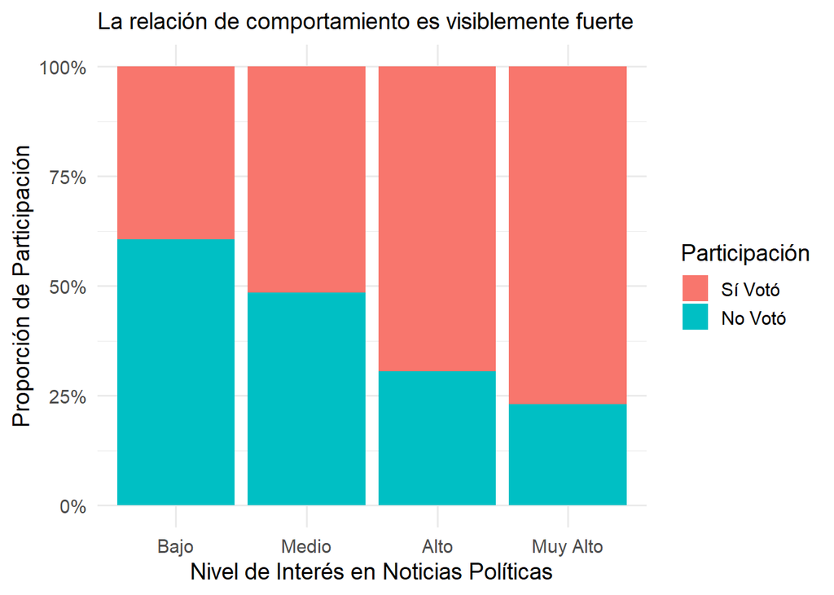

### **La Estrategia Inteligente: De la Demografía al Engagement**

Este hallazgo tiene implicaciones directas y rentables para cualquier organización cívica:

1. **Re-enfocar la Inversión:** Mover el presupuesto de campañas demográficas masivas a un targeting preciso basado en el **engagement y el interés** del usuario.
2. **Nutrir, Luego Pedir:** En lugar de pedir el voto directamente, la estrategia más efectiva es primero **nutrir el interés cívico** con contenido relevante.

Este enfoque no solo es más eficiente, sino también más respetuoso con la audiencia, creando un círculo virtuoso de participación informada.